# EDA - Census Data

Ajay Tom

2023-03-20

## 1. INTRODUCTION

In today’s digital age, high-speed internet has become a necessity for people and businesses alike. With the advent of 5G, the latest and fastest wireless technology, internet speeds have reached a new level of lightning-fast connectivity. Our client, a leading telecom company called “ConnectX”, has recognized the immense potential of this technology and aims to expand its 5G network across India. However, with a country as diverse and vast as India, rolling out 5G poses unique challenges. ConnectX understands the need to strategically plan and prioritize their 5G deployment in order to maximize their investments and provide the best possible service to their customers. In this report, we analyze India’s census data to help ConnectX make data-driven decisions to optimize their 5G rollout strategy.

**PROBLEM STATEMENT:** How can we analyze India’s census data to help ConnectX, a leading telecom company, make data-driven decisions and optimize their 5G rollout strategy?

## Import Dataset

```r
library(readxl)
census_data <- read_excel("D:\\GitHub\\EDA-census_data\\A-1_NO_OF_VILLAGES_TOWNS_HOUSEHOLDS_POPULATION_AND_AREA.xlsx")
```

## 2. HEADER CLEANING

```r
library(DT)
head(census_data)
```

```
## # A tibble: 6 × 15
##   State  C…¹ Distr…² Sub D…³ India…⁴ Name  Total…⁵ Numbe…⁶ ...8  Numbe…⁷ Numbe…⁸
##   <chr>      <chr>   <chr>   <chr>   <chr> <chr>   <chr>   <chr>   <dbl>   <dbl>
## 1 <NA>       <NA>    <NA>    <NA>    <NA>  <NA>    Inhabi… Unin…      NA NA
## 2 1          2       3       4       5     6       7       8           9  1   e1
## 3 00         000     00000   INDIA   INDI… Total   597608  43324    7933  2.50e8
## 4 00         000     00000   INDIA   INDI… Rural   597608  43324       0  1.69e8
## 5 00         000     00000   INDIA   INDI… Urban   0       0        7933  8.09e7
## 6 01         000     00000   STATE   JAMM… Total   6337    216       122  2.12e6
## # … with 5 more variables: Population <chr>, ...12 <chr>, ...13 <chr>,
## #   `Area\r\n (In sq. km)` <dbl>, `Population per sq. km.` <dbl>, and
## #   abbreviated variable names ¹`State  Code`, ²`District Code`,
## #   ³`Sub District Code`,
## #   ⁴`India/ State/ Union Territory/ District/ Sub-district`,
## #   ⁵`Total/\r\nRural/\r\nUrban`, ⁶`Number of villages`, ⁷`Number of towns`,
## #   ⁸`Number of households`
```

There are multiple header columns present in the dataset. These must be simplified and made one for better analysis.

## Deleting 2nd row

```r
census_data <- census_data[-2,]
head(census_data)
```

```
## # A tibble: 6 × 15
##   State  C…¹ Distr…² Sub D…³ India…⁴ Name  Total…⁵ Numbe…⁶ ...8  Numbe…⁷ Numbe…⁸
##   <chr>      <chr>   <chr>   <chr>   <chr> <chr>   <chr>   <chr>   <dbl>   <dbl>
## 1 <NA>       <NA>    <NA>    <NA>    <NA>  <NA>    Inhabi… Unin…      NA NA
## 2 00         000     00000   INDIA   INDI… Total   597608  43324    7933  2.50e8
## 3 00         000     00000   INDIA   INDI… Rural   597608  43324       0  1.69e8
## 4 00         000     00000   INDIA   INDI… Urban   0       0        7933  8.09e7
## 5 01         000     00000   STATE   JAMM… Total   6337    216       122  2.12e6
## 6 01         000     00000   STATE   JAMM… Rural   6337    216         0  1.55e6
## # … with 5 more variables: Population <chr>, ...12 <chr>, ...13 <chr>,
## #   `Area\r\n (In sq. km)` <dbl>, `Population per sq. km.` <dbl>, and
## #   abbreviated variable names ¹`State  Code`, ²`District Code`,
## #   ³`Sub District Code`,
## #   ⁴`India/ State/ Union Territory/ District/ Sub-district`,
## #   ⁵`Total/\r\nRural/\r\nUrban`, ⁶`Number of villages`, ⁷`Number of towns`,
## #   ⁸`Number of households`
```

## Rename Columns

```r
library(dplyr)
names(census_data) #to see the names of the columns
```

```
##  [1] "State  Code"
##  [2] "District Code"
##  [3] "Sub District Code"
##  [4] "India/ State/ Union Territory/ District/ Sub-district"
##  [5] "Name"
##  [6] "Total/\r\nRural/\r\nUrban"
##  [7] "Number of villages"
##  [8] "...8"
##  [9] "Number of towns"
## [10] "Number of households"
## [11] "Population"
## [12] "...12"
## [13] "...13"
## [14] "Area\r\n (In sq. km)"
## [15] "Population per sq. km."
```

```r
  #changed 'Number of villages' column to NV_Inhabited
  census_data <- rename(census_data, NV_Inhabited = "Number of villages")
  #changed '...8' column to NV_Uninhabited
  census_data <- rename(census_data, NV_Uninhabited = "...8")

  #changed the population super column to 3 seperate columns
  #P_Total, P_Males and P_Females
  census_data <- rename(census_data, P_Total = "Population")
  census_data <- rename(census_data, P_Males = "...12")
  census_data <- rename(census_data, P_Females = "...13")

names(census_data)
```

```
##  [1] "State  Code"
##  [2] "District Code"
##  [3] "Sub District Code"
##  [4] "India/ State/ Union Territory/ District/ Sub-district"
##  [5] "Name"
##  [6] "Total/\r\nRural/\r\nUrban"
##  [7] "NV_Inhabited"
##  [8] "NV_Uninhabited"
##  [9] "Number of towns"
## [10] "Number of households"
## [11] "P_Total"
## [12] "P_Males"
## [13] "P_Females"
## [14] "Area\r\n (In sq. km)"
## [15] "Population per sq. km."
```

## Delete the redundant 1st row

```r
census_data <- census_data[-1,]
head(census_data)
```

```
## # A tibble: 6 × 15
##   State …¹ Distr…² Sub D…³ India…⁴ Name  Total…⁵ NV_In…⁶ NV_Un…⁷ Numbe…⁸ Numbe…⁹
##   <chr>    <chr>   <chr>   <chr>   <chr> <chr>   <chr>   <chr>     <dbl>   <dbl>
## 1 00       000     00000   INDIA   INDI… Total   597608  43324      7933  2.50e8
## 2 00       000     00000   INDIA   INDI… Rural   597608  43324         0  1.69e8
## 3 00       000     00000   INDIA   INDI… Urban   0       0          7933  8.09e7
## 4 01       000     00000   STATE   JAMM… Total   6337    216         122  2.12e6
## 5 01       000     00000   STATE   JAMM… Rural   6337    216           0  1.55e6
## 6 01       000     00000   STATE   JAMM… Urban   0       0           122  5.66e5
## # … with 5 more variables: P_Total <chr>, P_Males <chr>, P_Females <chr>,
## #   `Area\r\n (In sq. km)` <dbl>, `Population per sq. km.` <dbl>, and
## #   abbreviated variable names ¹`State  Code`, ²`District Code`,
## #   ³`Sub District Code`,
## #   ⁴`India/ State/ Union Territory/ District/ Sub-district`,
## #   ⁵`Total/\r\nRural/\r\nUrban`, ⁶NV_Inhabited, ⁷NV_Uninhabited,
## #   ⁸`Number of towns`, ⁹`Number of households`
```

## 3. DATA UNDERSTANDING

```r
library(tidyverse)
str(census_data)
```

```
## tibble [20,020 × 15] (S3: tbl_df/tbl/data.frame)
##  $ State  Code                                          : chr [1:20020] "00" "00" "00" "01" ...
##  $ District Code                                        : chr [1:20020] "000" "000" "000" "000" ...
##  $ Sub District Code                                    : chr [1:20020] "00000" "00000" "00000" "00000" ...
##  $ India/ State/ Union Territory/ District/ Sub-district: chr [1:20020] "INDIA" "INDIA" "INDIA" "STATE" ...
##  $ Name                                                 : chr [1:20020] "INDIA @&" "INDIA $" "INDIA $" "JAMMU & KASHMIR @&" ...
##  $ Total/
## Rural/
## Urban                            : chr [1:20020] "Total" "Rural" "Urban" "Total" ...
##  $ NV_Inhabited                                         : chr [1:20020] "597608" "597608" "0" "6337" ...
##  $ NV_Uninhabited                                       : chr [1:20020] "43324" "43324" "0" "216" ...
##  $ Number of towns                                      : num [1:20020] 7933 0 7933 122 0 ...
##  $ Number of households                                 : num [1:20020] 2.50e+08 1.69e+08 8.09e+07 2.12e+06 1.55e+06 ...
##  $ P_Total                                              : chr [1:20020] "1210854977" "833748852" "377106125" "12541302" ...
##  $ P_Males                                              : chr [1:20020] "623270258" "427781058" "195489200" "6640662" ...
##  $ P_Females                                            : chr [1:20020] "587584719" "405967794" "181616925" "5900640" ...
##  $ Area
##  (In sq. km)                                 : num [1:20020] 3287469 3101474 102252 222236 220990 ...
##  $ Population per sq. km.                               : num [1:20020] 382 279 3685 124 91 ...
```

```r
glimpse(census_data)
```

```
## Rows: 20,020
## Columns: 15
## $ `State  Code`                                           <chr> "00", "00", "0…
## $ `District Code`                                         <chr> "000", "000", …
## $ `Sub District Code`                                     <chr> "00000", "0000…
## $ `India/ State/ Union Territory/ District/ Sub-district` <chr> "INDIA", "INDI…
## $ Name                                                    <chr> "INDIA @&", "I…
## $ `Total/\r\nRural/\r\nUrban`                             <chr> "Total", "Rura…
## $ NV_Inhabited                                            <chr> "597608", "597…
## $ NV_Uninhabited                                          <chr> "43324", "4332…
## $ `Number of towns`                                       <dbl> 7933, 0, 7933,…
## $ `Number of households`                                  <dbl> 249501663, 168…
## $ P_Total                                                 <chr> "1210854977", …
## $ P_Males                                                 <chr> "623270258", "…
## $ P_Females                                               <chr> "587584719", "…
## $ `Area\r\n (In sq. km)`                                  <dbl> 3287469.00, 31…
## $ `Population per sq. km.`                                <dbl> 382, 279, 3685…
```

```r
names(census_data)
```

```
##  [1] "State  Code"
##  [2] "District Code"
##  [3] "Sub District Code"
##  [4] "India/ State/ Union Territory/ District/ Sub-district"
##  [5] "Name"
##  [6] "Total/\r\nRural/\r\nUrban"
##  [7] "NV_Inhabited"
##  [8] "NV_Uninhabited"
##  [9] "Number of towns"
## [10] "Number of households"
## [11] "P_Total"
## [12] "P_Males"
## [13] "P_Females"
## [14] "Area\r\n (In sq. km)"
## [15] "Population per sq. km."
```

## 4. MISSING VALUES

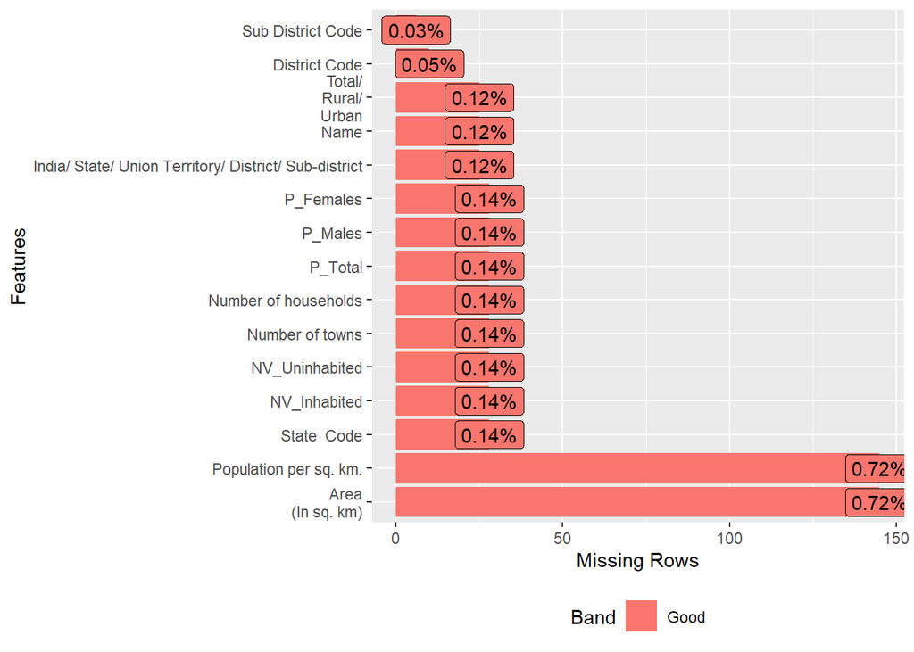

```r
library(DataExplorer)
plot_missing(census_data)
```

## 5. JUNK VALUES

Apart from the NAs, there are some junk values in the observations which if not handled, would impact the analysis

```r
unique(census_data$`District Code`)
```

```
##   [1] "000"   "001"   "002"   "003"   "004"   "005"   "006"   "007"   "008"
##  [10] "009"   "010"   "011"   "012"   "013"   "014"   "015"   "016"   "017"
##  [19] "018"   "019"   "020"   "021"   "022"   "023"   "024"   "025"   "026"
##  [28] "027"   "028"   "029"   "030"   "031"   "032"   "033"   "034"   "035"
##  [37] "036"   "037"   "038"   "039"   "040"   "041"   "042"   "043"   "044"
##  [46] "045"   "046"   "047"   "048"   "049"   "050"   "051"   "052"   "053"
##  [55] "054"   "055"   "056"   "057"   "058"   "059"   "060"   "061"   "062"
##  [64] "063"   "064"   "065"   "066"   "067"   "068"   "069"   "070"   "071"
##  [73] "072"   "073"   "074"   "075"   "076"   "077"   "078"   "079"   "080"
##  [82] "081"   "082"   "083"   "084"   "085"   "086"   "087"   "088"   "089"
##  [91] "090"   "091"   "092"   "093"   "094"   "095"   "096"   "097"   "098"
## [100] "099"   "100"   "101"   "102"   "103"   "104"   "105"   "106"   "107"
## [109] "108"   "109"   "110"   "111"   "112"   "113"   "114"   "115"   "116"
## [118] "117"   "118"   "119"   "120"   "121"   "122"   "123"   "124"   "125"
## [127] "126"   "127"   "128"   "129"   "130"   "131"   "132"   "133"   "134"
```

[output cut: 59 more lines]

```r
unique(census_data$`India/ State/ Union Territory/ District/ Sub-district`)
```

```
## [1] "INDIA"        "STATE"        "DISTRICT"     "SUB-DISTRICT" NA
## [6] "total"        "7687.39"      "10137.61"
```

```r
unique(census_data$`Total/\r\nRural/\r\nUrban`)
```

```
## [1] "Total"              "Rural"              "Urban"
## [4] NA                   "106.16"             "309.35000000000002"
```

## Filtering out

**1. District Code**

Filtering out non numeric values from **‘census_data’** and saving it in a new dataframe **‘census_data_filtered’**

```r
census_data_filtered <- census_data %>%
                            filter(!grepl("[^0-9]",`District Code`))
```

Filtering out the rows having 1,2,3,4 and 5 as District Code values

```r
census_data_filtered <- census_data_filtered %>%
                            filter(!`District Code` %in% c(1,2,3,4,5))
```

**2. Sub District Code**

Filtering out non numeric values from **Sub District Code**

```r
census_data_filtered <- census_data_filtered %>%
                            filter(!grepl("[^0-9]",`Sub District Code`))
```

**3. Number of households**

Replace 1e+05 with 100000 - R was only displaying 100000 as 1e+05. To display it as 100000:

```r
options(scipen = 999)
```

**4. Area(In sq. km)**

Filter out the junk files(excluding NAs)

```r
  census_data_filtered <- census_data_filtered %>%
    filter(is.na(`Area\r\n (In sq. km)`) |
           (grepl("^\\d+\\.?\\d*$", `Area\r\n (In sq. km)`)))
```

**5. Remove special characters from Name column (eg. INDIA @& to INDIA)**

Filter out the junk values brought down the number of observations from 20020 to 19995

```r
head(census_data_filtered$Name)
```

```
## [1] "INDIA @&"           "INDIA $"            "INDIA $"
## [4] "JAMMU & KASHMIR @&" "JAMMU & KASHMIR"    "JAMMU & KASHMIR"
```

```r
  census_data_filtered <- census_data_filtered %>%
                            mutate(Name = str_replace_all(Name, "@&", ""))
  census_data_filtered <- census_data_filtered %>%
                            mutate(Name = str_replace_all(Name, "\\$", ""))

head(census_data_filtered$Name)
```

```
## [1] "INDIA "           "INDIA "           "INDIA "           "JAMMU & KASHMIR "
## [5] "JAMMU & KASHMIR"  "JAMMU & KASHMIR"
```

**Observations Reduced**

Filter out the junk values brought down the number of observations from 20020 to 19995

```r
  nrow(census_data)
```

```
## [1] 20020
```

```r
  nrow(census_data_filtered)
```

```
## [1] 19995
```

## 6. TYPE CONVERSION

Converting columns into appropriate data types

```r
census_data_filtered$`State  Code` <- as.factor(census_data_filtered$`State  Code`)
  census_data_filtered$`District Code` <- as.factor(census_data_filtered$`District Code`)
  census_data_filtered$`Sub District Code` <- as.factor(census_data_filtered$`Sub District Code`)
  census_data_filtered$`India/ State/ Union Territory/ District/ Sub-district` <- as.factor(census_data_filtered$`India/ State/ Union Territory/ District/ Sub-district`)
  census_data_filtered$`Name` <- as.character(census_data_filtered$`Name`)
  census_data_filtered$`Total/\r\nRural/\r\nUrban` <- as.factor(census_data_filtered$`Total/\r\nRural/\r\nUrban`)
  census_data_filtered$`NV_Inhabited` <- as.numeric(census_data_filtered$`NV_Inhabited`)
  census_data_filtered$`NV_Uninhabited` <- as.numeric(census_data_filtered$`NV_Uninhabited`)
  census_data_filtered$`Number of towns` <- as.numeric(census_data_filtered$`Number of towns`)
  census_data_filtered$`Number of households` <- as.numeric(census_data_filtered$`Number of households`)
  census_data_filtered$`P_Total` <- as.numeric(census_data_filtered$`P_Total`)
  census_data_filtered$`P_Males` <- as.numeric(census_data_filtered$`P_Males`)
  census_data_filtered$`P_Females` <- as.numeric(census_data_filtered$`P_Females`)
  census_data_filtered$`Area\r\n (In sq. km)` <- as.numeric(census_data_filtered$`Area\r\n (In sq. km)`)
  census_data_filtered$`Population per sq. km.` <- as.numeric(census_data_filtered$`Population per sq. km.`)


glimpse(census_data_filtered)
```

```
## Rows: 19,995
## Columns: 15
## $ `State  Code`                                           <fct> 00, 00, 00, 01…
## $ `District Code`                                         <fct> 000, 000, 000,…
## $ `Sub District Code`                                     <fct> 00000, 00000, …
## $ `India/ State/ Union Territory/ District/ Sub-district` <fct> INDIA, INDIA, …
## $ Name                                                    <chr> "INDIA ", "IND…
## $ `Total/\r\nRural/\r\nUrban`                             <fct> Total, Rural, …
## $ NV_Inhabited                                            <dbl> 597608, 597608…
## $ NV_Uninhabited                                          <dbl> 43324, 43324, …
## $ `Number of towns`                                       <dbl> 7933, 0, 7933,…
## $ `Number of households`                                  <dbl> 249501663, 168…
## $ P_Total                                                 <dbl> 1210854977, 83…
## $ P_Males                                                 <dbl> 623270258, 427…
## $ P_Females                                               <dbl> 587584719, 405…
## $ `Area\r\n (In sq. km)`                                  <dbl> 3287469.00, 31…
## $ `Population per sq. km.`                                <dbl> 382, 279, 3685…
```

## 7. DATA DICTIONARY

```r
variable_names <- colnames(census_data_filtered)

  library(purrr)
  variable_type <- map_chr(census_data_filtered, class)

  description <- c("Official code of each state","Official code of each disctrict","Official code of each sub district", "Classified as State, Union Territory, District, Sub-district, or the entire country - India",
                   "Name of the State, Union Territory, District, Sub-district, or the entire country - India", "Classified as Urban area and Rural area.",
                   "Number of villages inhabited","Number of villages uninhabited","Number of towns in the area", "Number of households in the area","Total population in the area","Total male population in the area",
                   "Total female population in the area", "Total area of the region in square kilometer", "Number of people per square kilometer")

  data_dict <- data.frame(variable_names,variable_type,description)
  rownames(census_data_filtered) <- NULL
  data_dict <- data.frame(data_dict, row.names = 1:ncol(census_data_filtered))



library(DT)
datatable(data_dict)
```

|  | variable_names | variable_type | description |
| --- | --- | --- | --- |
| 1 | State Code | factor | Official code of each state |
| 2 | District Code | factor | Official code of each disctrict |
| 3 | Sub District Code | factor | Official code of each sub district |
| 4 | India/ State/ Union Territory/ District/ Sub-district | factor | Classified as State, Union Territory, District, Sub-district, or the entire country - India |
| 5 | Name | character | Name of the State, Union Territory, District, Sub-district, or the entire country - India |
| 6 | Total/ Rural/ Urban | factor | Classified as Urban area and Rural area. |
| 7 | NV_Inhabited | numeric | Number of villages inhabited |
| 8 | NV_Uninhabited | numeric | Number of villages uninhabited |
| 9 | Number of towns | numeric | Number of towns in the area |
| 10 | Number of households | numeric | Number of households in the area |

[output cut: 5 more lines]

## 8. HANDLING MISSING VALUES

Out of 122 observations having at least 1 NA in all the columns, 117 observations are having valid values in 13 columns. Only 5 are having NAs in all the columns.

```r
display_df <- census_data_filtered %>%
    filter_all(any_vars(is.na(.)))
datatable(display_df)
```

|  | State Code | District Code | Sub District Code | India/ State/ Union Territory/ District/ Sub-district | Name | Total/ Rural/ Urban | NV_Inhabited | NV_Uninhabited | Number of towns | Number of households | P_Total | P_Males | P_Females | Area (In sq. km) | Population per sq. km. |
| --- | --- | --- | --- | --- | --- | --- | --- | --- | --- | --- | --- | --- | --- | --- | --- |
| 1 | 12 | 000 | 00000 | STATE | ARUNACHAL PRADESH | Rural | 5258 | 331 | 0 | 200210 | 1066358 | 546011 | 520347 |  |  |
| 2 | 12 | 000 | 00000 | STATE | ARUNACHAL PRADESH | Urban | 0 | 0 | 27 | 70367 | 317369 | 167901 | 149468 |  |  |
| 3 | 12 | 245 | 00000 | DISTRICT | Tawang | Rural | 218 | 17 | 0 | 8377 | 38775 | 20792 | 17983 |  |  |
| 4 | 12 | 245 | 00000 | DISTRICT | Tawang | Urban | 0 | 0 | 1 | 1685 | 11202 | 8359 | 2843 |  |  |
| 5 | 12 | 245 | 01559 | SUB-DISTRICT | TAWANG CIRCLE | Rural | 63 | 14 | 0 | 1785 | 7897 | 4104 | 3793 |  |  |
| 6 | 12 | 245 | 01559 | SUB-DISTRICT | TAWANG CIRCLE | Urban | 0 | 0 | 1 | 1685 | 11202 | 8359 | 2843 |  |  |
| 7 | 12 | 246 | 00000 | DISTRICT | West Kameng | Rural | 260 | 23 | 0 | 14069 | 68015 | 37809 | 30206 |  |  |
| 8 | 12 | 246 | 00000 | DISTRICT | West Kameng | Urban | 0 | 0 | 3 | 4090 | 15932 | 8346 | 7586 |  |  |
| 9 | 12 | 246 | 01566 | SUB-DISTRICT | Dirang | Rural | 81 | 7 | 0 | 3178 | 14651 | 7776 | 6875 |  |  |
| 10 | 12 | 246 | 01566 | SUB-DISTRICT | Dirang | Urban | 0 | 0 | 1 | 966 | 3750 | 1928 | 1822 |  |  |

[output cut: 112 more lines]

```r
display_df <- census_data_filtered %>%
    filter_all(all_vars(is.na(.)))
datatable(display_df)
```

|  | State Code | District Code | Sub District Code | India/ State/ Union Territory/ District/ Sub-district | Name | Total/ Rural/ Urban | NV_Inhabited | NV_Uninhabited | Number of towns | Number of households | P_Total | P_Males | P_Females | Area (In sq. km) | Population per sq. km. |
| --- | --- | --- | --- | --- | --- | --- | --- | --- | --- | --- | --- | --- | --- | --- | --- |
| 1 |  |  |  |  |  |  |  |  |  |  |  |  |  |  |  |
| 2 |  |  |  |  |  |  |  |  |  |  |  |  |  |  |  |
| 3 |  |  |  |  |  |  |  |  |  |  |  |  |  |  |  |
| 4 |  |  |  |  |  |  |  |  |  |  |  |  |  |  |  |
| 5 |  |  |  |  |  |  |  |  |  |  |  |  |  |  |  |

## Deleting these 5 rows

```r
census_data_filtered <- census_data_filtered %>%
                            filter_all(any_vars(!is.na(.)))

display_df <- census_data_filtered %>%
    filter_all(all_vars(is.na(.)))
datatable(display_df)
```

|  | State Code | District Code | Sub District Code | India/ State/ Union Territory/ District/ Sub-district | Name | Total/ Rural/ Urban | NV_Inhabited | NV_Uninhabited | Number of towns | Number of households | P_Total | P_Males | P_Females | Area (In sq. km) | Population per sq. km. |
| --- | --- | --- | --- | --- | --- | --- | --- | --- | --- | --- | --- | --- | --- | --- | --- |

## Categorical Variable Distribution

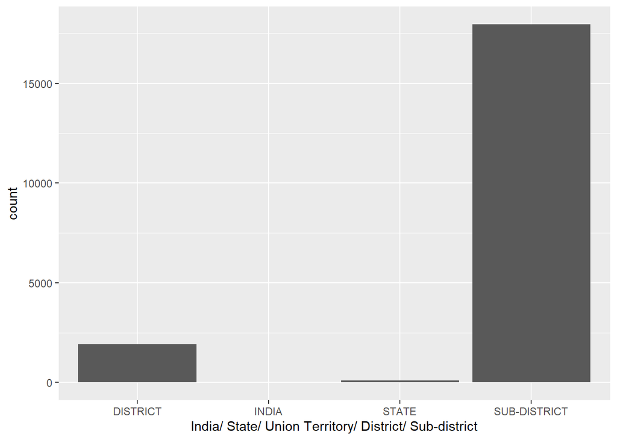

```r
ggplot(data = census_data_filtered, aes(x = `India/ State/ Union Territory/ District/ Sub-district`))+
  geom_bar()
```

## To develop a comprehensive strategy for our client, we will filter the census dataset to focus on granular details. Specifically, we will analyze the dataset at the district level to gain deeper insights and provide actionable recommendations.

```r
census_data_dist <- census_data_filtered %>%
    filter(`India/ State/ Union Territory/ District/ Sub-district` == 'DISTRICT')
```

## Continuous Variable Distribution

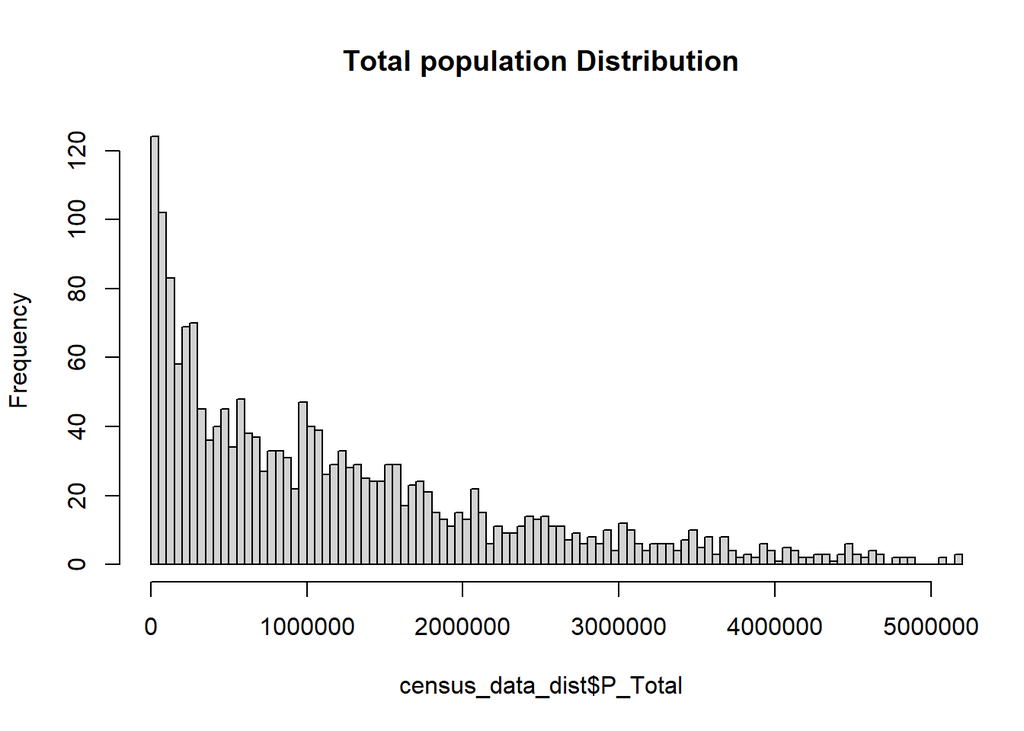

```r
hist(census_data_dist$P_Total, breaks = 250,
       main = "Total population Distribution", xlim = c(0,5000000))
```

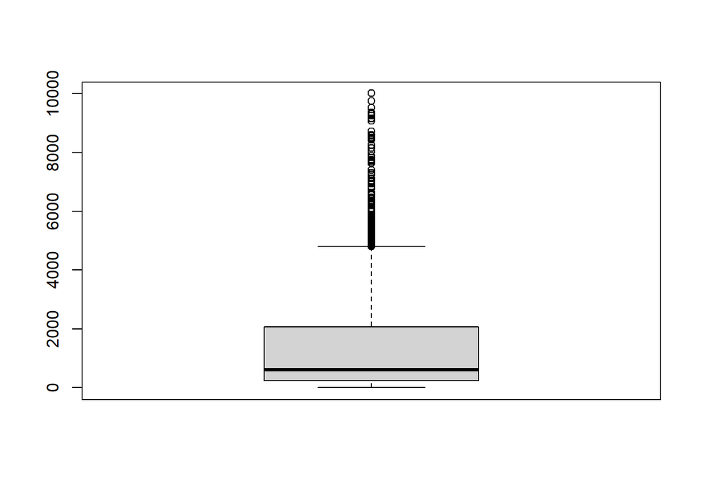

```r
  boxplot(census_data_dist$`Population per sq. km.`, ylim = c(0,10000))
```

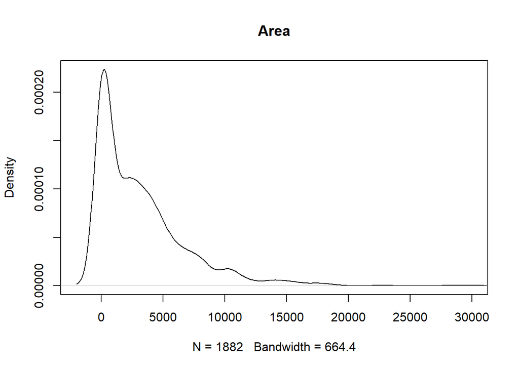

```r
  plot(density(census_data_dist$`Area\r\n (In sq. km)`, na.rm = TRUE), xlim = c(-2000,30000), main = "Area")
```

## 10. Imputation

## Simple Imputation

**Area(In sq. km)**

```r
census_data_imputed <- census_data_dist
summary(census_data_imputed$`Area\r\n (In sq. km)`)
```

```
##    Min. 1st Qu.  Median    Mean 3rd Qu.    Max.    NA's
##     0.0   185.3  2247.5  3320.7  4654.5 45674.0      37
```

```r
min_val <- min(census_data_imputed$`Area\r\n (In sq. km)`, na.rm = TRUE)
  max_val <- max(census_data_imputed$`Area\r\n (In sq. km)`, na.rm = TRUE)

  imputed_vals <- runif(sum(is.na(census_data_imputed$`Area\r\n (In sq. km)`)), min = min_val, max = max_val)

  census_data_imputed$`Area\r\n (In sq. km)`[which(is.na(census_data_imputed$`Area\r\n (In sq. km)`))] <- imputed_vals


summary(census_data_imputed$`Area\r\n (In sq. km)`)
```

```
##    Min. 1st Qu.  Median    Mean 3rd Qu.    Max.
##       0     198    2311    3700    4861   45674
```

**Population per sq. km.**

Population per sq. km. can be calculated by dividing the imputed values of Area (In sq. km) by corresponding P_Total

```r
summary(census_data_imputed$`Population per sq. km.`)
```

```
##    Min. 1st Qu.  Median    Mean 3rd Qu.    Max.    NA's
##     0.0   241.2   609.4  1716.5  2064.8 46867.0      37
```

```r
  census_data_imputed$`Population per sq. km.`[which(is.na(census_data_imputed$`Population per sq. km.`))]
```

```
##  [1] NA NA NA NA NA NA NA NA NA NA NA NA NA NA NA NA NA NA NA NA NA NA NA NA NA
## [26] NA NA NA NA NA NA NA NA NA NA NA NA
```

```r
  pd_imputed_vals <-  census_data_imputed$`Area\r\n (In sq. km)`[which(is.na(census_data_imputed$`Population per sq. km.`))]/census_data_imputed$P_Total[which(is.na(census_data_imputed$`Population per sq. km.`))]


  census_data_imputed$`Population per sq. km.`[which(is.na(census_data_imputed$`Population per sq. km.`))] <- pd_imputed_vals

summary(census_data_imputed$`Population per sq. km.`)
```

```
##    Min. 1st Qu.  Median    Mean 3rd Qu.    Max.
##     0.0   229.1   587.0  1683.4  2022.7 46867.0
```

## 10. Uni-Variate Analysis(After Imputation)

## Comparison

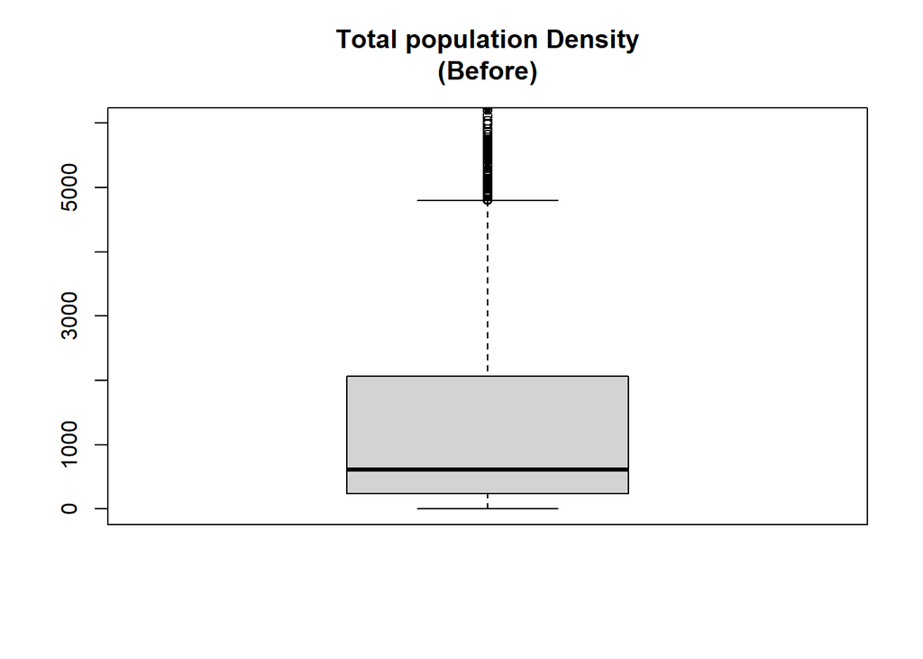

```r
boxplot(census_data_dist$`Population per sq. km.`,
          main = "Total population Density\n(Before)", ylim = c(0,6000))
```

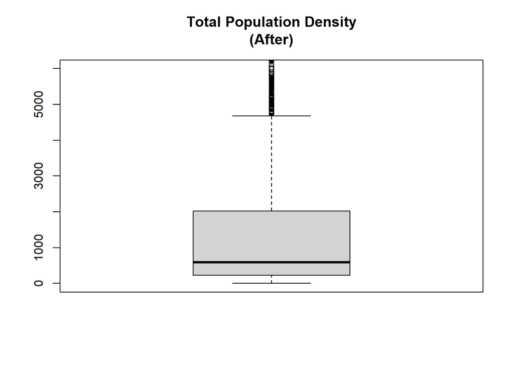

```r
  boxplot(census_data_imputed$`Population per sq. km.`,
          main = "Total Population Density\n(After)", ylim = c(0,6000))
```

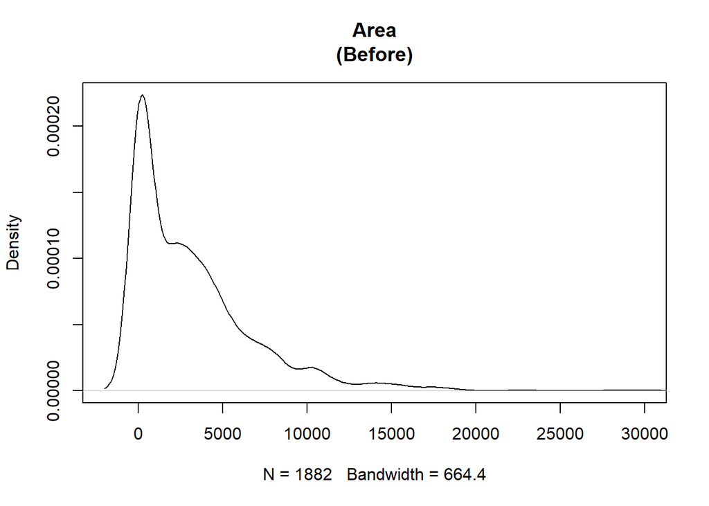

```r
  plot(density(census_data_dist$`Area\r\n (In sq. km)`, na.rm = TRUE), xlim = c(-2000,30000), main = "Area\n(Before)")
```

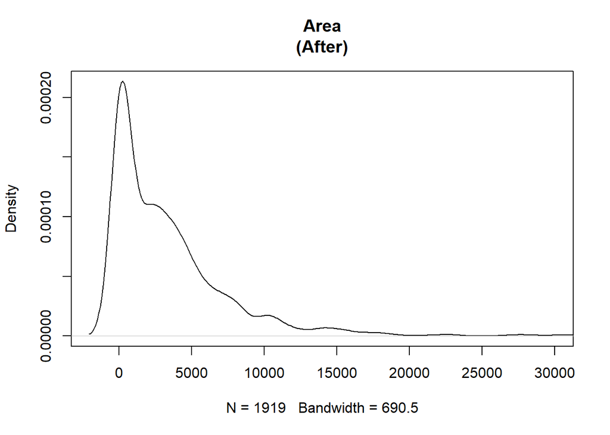

```r
  plot(density(census_data_imputed$`Area\r\n (In sq. km)`), xlim = c(-2000,30000), main = "Area\n(After)")
```

The before and after comparison shows no significant difference, suggesting good imputation.

## 11. Bi-Variate Analysis

```r
  cor(census_data_imputed[7:15])
```

```
##                        NV_Inhabited NV_Uninhabited Number of towns
## NV_Inhabited             1.00000000     0.66970839     -0.08634972
## NV_Uninhabited           0.66970839     1.00000000     -0.07179148
## Number of towns         -0.08634972    -0.07179148      1.00000000
## Number of households     0.48706433     0.26115482      0.39811045
## P_Total                  0.54062055     0.30691824      0.35716170
## P_Males                  0.53330806     0.30509898      0.35020369
## P_Females                0.54765879     0.30841101      0.36409432
## Area\r\n (In sq. km)     0.35888077     0.14890183     -0.08810027
## Population per sq. km.  -0.31876676    -0.18068679      0.14104364
##                        Number of households    P_Total    P_Males  P_Females
## NV_Inhabited                     0.48706433 0.54062055 0.53330806 0.54765879
## NV_Uninhabited                   0.26115482 0.30691824 0.30509898 0.30841101
## Number of towns                  0.39811045 0.35716170 0.35020369 0.36409432
## Number of households             1.00000000 0.97938473 0.97642787 0.98109110
## P_Total                          0.97938473 1.00000000 0.99932681 0.99922455
## P_Males                          0.97642787 0.99932681 1.00000000 0.99710738
## P_Females                        0.98109110 0.99922455 0.99710738 1.00000000
## Area\r\n (In sq. km)             0.23414480 0.22813745 0.22323143 0.23306105
## Population per sq. km.           0.07001446 0.05904563 0.06705305 0.05036328
##                        Area\r\n (In sq. km) Population per sq. km.
## NV_Inhabited                     0.35888077            -0.31876676
## NV_Uninhabited                   0.14890183            -0.18068679
## Number of towns                 -0.08810027             0.14104364
## Number of households             0.23414480             0.07001446
## P_Total                          0.22813745             0.05904563
## P_Males                          0.22323143             0.06705305
## P_Females                        0.23306105             0.05036328
## Area\r\n (In sq. km)             1.00000000            -0.29371380
## Population per sq. km.          -0.29371380             1.00000000
```

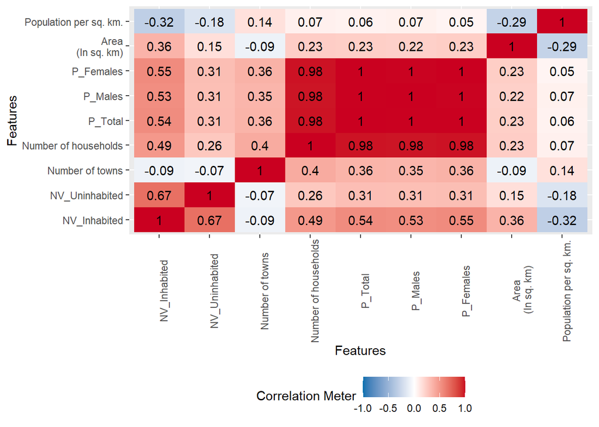

```r
  plot_correlation(census_data_imputed[7:15])
```

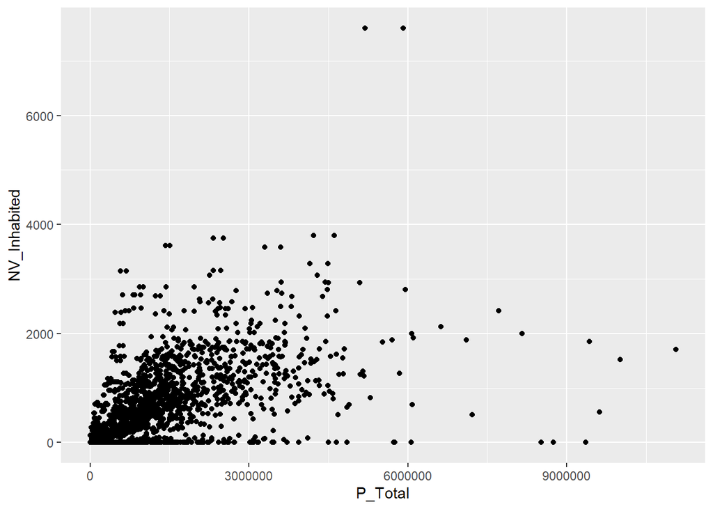

```r
  ggplot(census_data_imputed,aes(x=P_Total,y=NV_Inhabited))+
    geom_point()
```

## 12. Final Analysis

Upon examining the Boxplot of Population Density more closely, the presence of upper outliers appears to be a positive sign.

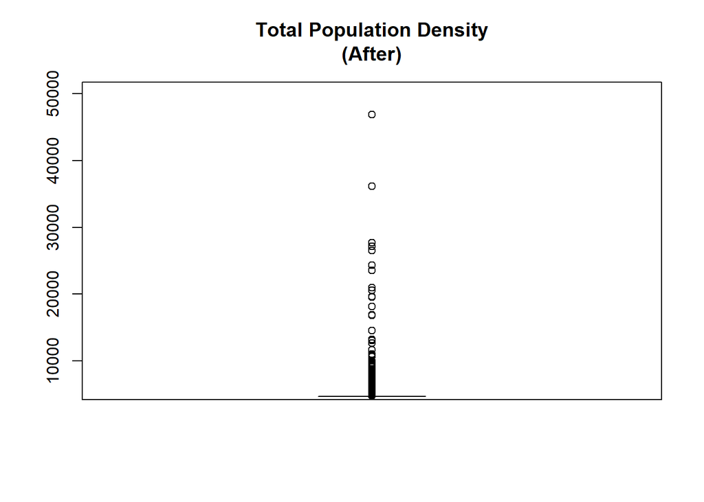

```r
boxplot(census_data_imputed$`Population per sq. km.`,
          main = "Total Population Density\n(After)", ylim = c(6000,50000))
```

```r
Recommended_list <- census_data_imputed %>%
                      filter(`Population per sq. km.` > 6000) %>%
                      filter(!duplicated(Name)) %>%
                      pull(Name)
```

Deleting the zones of Delhi and replacing all with ‘Delhi’

```r
Recommended_list <- Recommended_list[c(-9,-10,-11,-12,-13,-14,-15,-16)]

Recommended_list <- c(Recommended_list, "Delhi")
print(Recommended_list)
```

```
##  [1] "Kargil"                     "Kishtwar"
##  [3] "Ludhiana"                   "Amritsar"
##  [5] "Chandigarh"                 "Karnal"
##  [7] "Panipat"                    "Faridabad"
##  [9] "Saharanpur"                 "Muzaffarnagar"
## [11] "Bijnor"                     "Moradabad"
## [13] "Jyotiba Phule Nagar"        "Meerut"
## [15] "Ghaziabad"                  "Mahamaya Nagar"
## [17] "Agra"                       "Firozabad"
## [19] "Pilibhit"                   "Shahjahanpur"
## [21] "Lucknow"                    "Farrukhabad"
## [23] "Etawah"                     "Kanpur Nagar"
## [25] "Hamirpur"                   "Mahoba"
## [27] "Allahabad"                  "Bahraich"
## [29] "Shrawasti"                  "Varanasi"
```

[output cut: 21 more lines]

```r
phase1 <- c("Chandigarh", "Hyderabad", "Mumbai", "Pune", "Chennai", "Delhi")

phase2 <- c("Ludhiana", "Amritsar", "Karnal", "Panipat", "Faridabad", "Saharanpur", "Muzaffarnagar",
            "Meerut", "Ghaziabad", "Agra", "Lucknow", "Kanpur Nagar", "Allahabad", "Varanasi", "Patna",
            "Ahmadabad", "Surat", "Nagpur", "Thane", "Mumbai Suburban", "Bangalore")

phase3 <- c("Kargil", "Kishtwar", "Bijnor", "Moradabad", "Jyotiba Phule Nagar", "Firozabad",
            "Pilibhit", "Shahjahanpur", "Farrukhabad", "Etawah", "Hamirpur", "Mahoba", "Bahraich",
            "Shrawasti", "Etah", "Kanshiram Nagar", "Saharsa", "Muzaffarpur", "Siwan", "Vaishali",
            "Samastipur", "Khagaria", "Bhagalpur", "Munger", "Buxar", "Gaya", "Chandel", "Dhubri",
            "Dakshin Dinajpur", "Maldah", "North Twenty Four Parganas", "Hugli", "Haora",
            "Kolkata", "Purbi Singhbhum", "Kendrapara", "Morena", "Datia", "Indore", "Akola",
            "Koppal", "Ramanagara", "Puducherry","Mahamaya Nagar", "Latur")
```

## 13. Recommendation

The three phases of the rollout would be based on the categorization of the cities as follows:

Phase 1: Cities with the best 5G infrastructure and awareness among the public, including Chandigarh, Hyderabad, Mumbai, Pune, Chennai, and Delhi.

Phase 2: Cities with good 5G infrastructure and awareness among the public, but less than the cities in Phase 1. This includes Ludhiana, Amritsar, Karnal, Panipat, Faridabad, Saharanpur, Muzaffarnagar, Meerut, Ghaziabad, Agra, Lucknow, Kanpur Nagar, Allahabad, Varanasi, Patna, Ahmadabad, Surat, Nagpur, Thane, Mumbai Suburban, and Bangalore.

Phase 3: Cities with average 5G infrastructure and awareness among the public, but less than the cities in Phase 2. This includes cities such as Kargil, Kishtwar, Bijnor, Moradabad, Jyotiba Phule Nagar, Firozabad, Pilibhit, Shahjahanpur, Farrukhabad, Etawah, Hamirpur, Mahoba, Bahraich, Shrawasti, Etah, Kanshiram Nagar, Saharsa, Muzaffarpur, Siwan, Vaishali, Samastipur, Khagaria, Bhagalpur, Munger, Buxar, Gaya, Chandel, Dhubri, Dakshin Dinajpur, Maldah, North Twenty Four Parganas, Hugli, Haora, Kolkata, Purbi Singhbhum, Kendrapara, Morena, Datia, Indore, Akola, Koppal, Ramanagara, and Puducherry.

By following this phased approach, ConnectX can ensure a more efficient rollout of your 5G services, focusing on areas with the highest potential impact in each phase. This will also help the ConnectX to allocate resources more effectively and maximize the return on their investment.

```r
print(phase1)
```

```
## [1] "Chandigarh" "Hyderabad"  "Mumbai"     "Pune"       "Chennai"
## [6] "Delhi"
```

```r
print(phase2)
```

```
##  [1] "Ludhiana"        "Amritsar"        "Karnal"          "Panipat"
##  [5] "Faridabad"       "Saharanpur"      "Muzaffarnagar"   "Meerut"
##  [9] "Ghaziabad"       "Agra"            "Lucknow"         "Kanpur Nagar"
## [13] "Allahabad"       "Varanasi"        "Patna"           "Ahmadabad"
## [17] "Surat"           "Nagpur"          "Thane"           "Mumbai Suburban"
## [21] "Bangalore"
```

```r
print(phase3)
```

```
##  [1] "Kargil"                     "Kishtwar"
##  [3] "Bijnor"                     "Moradabad"
##  [5] "Jyotiba Phule Nagar"        "Firozabad"
##  [7] "Pilibhit"                   "Shahjahanpur"
##  [9] "Farrukhabad"                "Etawah"
## [11] "Hamirpur"                   "Mahoba"
## [13] "Bahraich"                   "Shrawasti"
## [15] "Etah"                       "Kanshiram Nagar"
## [17] "Saharsa"                    "Muzaffarpur"
## [19] "Siwan"                      "Vaishali"
## [21] "Samastipur"                 "Khagaria"
## [23] "Bhagalpur"                  "Munger"
## [25] "Buxar"                      "Gaya"
## [27] "Chandel"                    "Dhubri"
## [29] "Dakshin Dinajpur"           "Maldah"
## [31] "North Twenty Four Parganas" "Hugli"
## [33] "Haora"                      "Kolkata"
## [35] "Purbi Singhbhum"            "Kendrapara"
## [37] "Morena"                     "Datia"
## [39] "Indore"                     "Akola"
## [41] "Koppal"                     "Ramanagara"
## [43] "Puducherry"                 "Mahamaya Nagar"
## [45] "Latur"
```